```python
%matplotlib inline
```

# Facial Recognition Using Eigenfaces

In this notebook, we will create a simple facial recognition program. We will be using the **faces94** dataset. First we need our to import the necessary libraries.

```python
import numpy as np
from scipy import linalg as la
from os import walk
from scipy.ndimage import imread
from matplotlib import pyplot as plt
import matplotlib.cm as cm
import random
```

### Load Faces Dataset

We begin by creating a function to load all the faces. The code we will be using traverses through the given directory and loads all JPEG images. The images are flattened and then stored vertically in a matrix. For convenience, we will make the default path be the **./faces94** directory.

```python
def getFaces(path='./faces94'):
    """Traverse the directory specified by 'path' and return an array containing
    one column vector per subdirectory.
    """
    # Traverse the directory and get one image per subdirectory
    faces = []
    for (dirpath, dirnames, filenames) in walk(path):
        for f in filenames:
            if f[-3:]=="jpg": # only get jpg images
                # load image, convert to grayscale, flatten into vector
                face = imread(dirpath+"/"+f).mean(axis=2).ravel()
                faces.append(face)
                break
    # put all the face vectors column-wise into a matrix
    return np.array(faces).T
```

### Performing a Mean Shift on the Faces

To accentuate the unique features of each of the faces, we will perform a mean shift. First, we must calculate the mean face. We will store the faces using our **getFaces** function and then calculate the mean face $\mu$. The mean face is plotted below.

#### Calculate the Mean Face

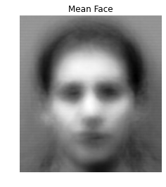

```python
F = getFaces() # store faces in variable F
mu = np.vstack(np.mean(F,axis=1)) # take the average of all the columns

#Plot the mean face.
plt.title("Mean Face")
plt.imshow(mu.reshape((200,180)),cmap=cm.Greys_r)
plt.axis("off")
plt.show()
```

#### Mean Face Shift

Now that we have calculated the mean face, we perform a mean shift on all the faces. We will refer to the mean shifted faces as $\bar{F}$. A few mean shifted faces are plotted below.

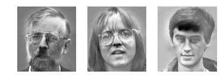

```python
Fbar = F - mu

#Plot a few mean shifted faces
plt.subplot(1,3,1)
plt.imshow(Fbar[:,14].reshape((200,180)),cmap=cm.Greys_r)
plt.axis("off")
plt.subplot(1,3,2)
plt.imshow(Fbar[:,35].reshape((200,180)),cmap=cm.Greys_r)
plt.axis("off")
plt.subplot(1,3,3)
plt.imshow(Fbar[:,44].reshape((200,180)),cmap=cm.Greys_r)
plt.axis("off")
plt.show()
```

### Take the SVD of the Mean-Shifted Faces to Generate Eigenfaces

Later in this notebook, we will be finding the closest match to an image using the 2-norm. Using the full image would be accurate, but it would require a lot of resources. To save on resources while still getting the best results possible, we will use the Singular Value decomposition.

```python
U,s,Vt = la.svd(Fbar,full_matrices=False)
```

### Project onto s-dimensional Subspace

We will project $\bar{F}$ and the inputed image to the column space of $U_s$ where $s$ is the number of eigenfaces we will be using to approximate the image. It can be shown mathematically that this is equivalent to left multiplying by $U^T_s$. We will refer to the projected mean faces as $\hat{F}.$ For our example, we will use $s=38$.

```python
s = 38
Fhat = U[:,:s].T.dot(Fbar)
```

### Find Closest Match

Given a query $g$, we will provide the closest match with respect to the Euclidean norm. Since we have a set of projected, mean-shifted faces, $g$ will also need to be shifted by the mean and projected onto the same s-dimensional subspace before we can do any comparisons. We will calculate $index$ of the closest match as follows: $$index = \text{argmin}_i \|\widehat{f}_i - \widehat{g}\|_2$$

This is accomplished in the following function:

```python
def findNearest(image, s=38):
    """Finds the closest match with respect to the Euclidean norm.
    Assumes that 'image' is a flattened representation of an image.
    """
    gbar = np.vstack(image) - mu
    ghat = np.vstack(U[:,:s].T.dot(gbar))
    index = np.argmin(np.linalg.norm(Fhat-ghat, axis=0, ord=2))
    return index
```

### Wrapping Up

Once we have found this index, we will look up that face in our dataset to verify that it is a reasonable answer. At this point, we are done. We will now verify that our code works by testing 5 images pulled at random from the dataset.

#### Create Sample Set of Faces

```python
def sampleFaces(n_tests, path="./faces94"):
    """Return an array containing a sample of n_tests images contained
    in the path as flattened images in the columns of the output
    """
    files = []
    for (dirpath, dirnames, filenames) in walk(path):
        for f in filenames:
            if f[-3:]=="jpg": # only get jpg images
                files.append(dirpath+"/"+f)

    #Get a sample of the images
    test_files = random.sample(files, n_tests)
    #Flatten and average the pixel values
    images = np.array([imread(f).mean(axis=2).ravel() for f in test_files]).T
    return images

test_images = sampleFaces(5)
```

#### Run Verification

Now we will return the results for 5 faces selected at random. The results are plotted below. On the left is the inputed image. On the right is the closest match. This plotting behavior is handled by the **show2** function.

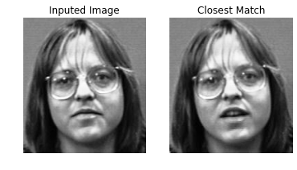

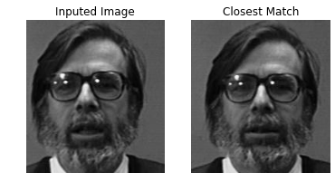

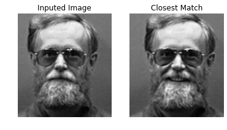

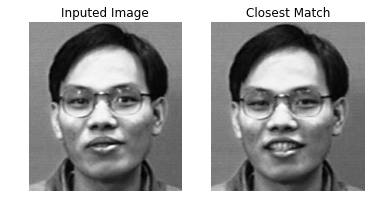

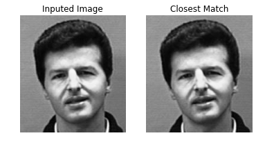

```python
def show2(test_image, result, w=200, h=180):
    """Convenience function for plotting two flattened grayscale images of
    the specified width and height side by side
    """
    plt.subplot(121)
    plt.title("Inputed Image")
    plt.imshow(test_image.reshape((w,h)), cmap=cm.Greys_r)
    plt.axis("off")
    plt.subplot(122)
    plt.title("Closest Match")
    plt.imshow(result.reshape((w,h)), cmap=cm.Greys_r)
    plt.axis("off")
    plt.show()

for i in xrange(len(test_images[0])):
    index = findNearest(test_images[:,i])
    show2(test_images[:,i], F[:,index])
```

## Complete Code Refactored as a Class

```python
import numpy as np
from scipy import linalg as la
from os import walk
from scipy.ndimage import imread
from matplotlib import pyplot as plt
import matplotlib.cm as cm
import random
class FacialRec:
    ##########Members##########
    # F, mu, Fbar, and U
    ###########################
    def __init__(self,path):
        self.initFaces(path)
        self.initMeanImage()
        self.initDifferences()
        self.initEigenfaces()
    def initFaces(self, path):
        self.F = self.getFaces(path)
    def initMeanImage(self):
        self.mu = np.vstack(np.mean(self.F,axis=1))
    def initDifferences(self):
        self.Fbar = self.F - self.mu
    def initEigenfaces(self):
        self.U, s, Vt = la.svd(self.Fbar,full_matrices=False)
    def project(self, A, s=38):
        Ut = self.U[:,:s].T
        A_s = Ut.dot(A)
        return Ut, A_s
    def findNearest(self, image, s=38):
        Ut, Fhat = self.project(self.Fbar, s)
        gbar = np.vstack(image) - self.mu
        ghat = np.vstack(Ut.dot(gbar))
        index = np.argmin(np.linalg.norm(Fhat-ghat, axis=0, ord=2))
        return index

    def getFaces(self, path):
        """Traverse the directory specified by 'path' and return an array containing
        one column vector per subdirectory.
        For the faces94 dataset, this gives an array with just one column for each
        face in the database. Each column corresponds to a flattened grayscale image.
        """
        # Traverse the directory and get one image per subdirectory
        faces = []
        for (dirpath, dirnames, filenames) in walk(path):
            for f in filenames:
                if f[-3:]=="jpg": # only get jpg images
                    # load image, convert to grayscale, flatten into vector
                    face = imread(dirpath+"/"+f).mean(axis=2).ravel()
                    faces.append(face)
                    break
        # put all the face vectors column-wise into a matrix
        return np.array(faces).T

def sampleFaces(n_tests, path):
    """Return an array containing a sample of n_tests images contained
    in the path as flattened images in the columns of the output
    """
    files = []
    for (dirpath, dirnames, filenames) in walk(path):
        for f in filenames:
            if f[-3:]=="jpg": # only get jpg images
                files.append(dirpath+"/"+f)

    #Get a sample of the images
    test_files = random.sample(files, n_tests)
    #Flatten and average the pixel values
    images = np.array([imread(f).mean(axis=2).ravel() for f in test_files]).T
    return images

def show(im, w=200, h=180):
    """Plot the flattened grayscale image 'im' of width 'w' and height 'h'."""
    plt.imshow(im.reshape((w,h)), cmap=cm.Greys_r)
    plt.show()

def show2(test_image, result, w=200, h=180):
    """Convenience function for plotting two flattened grayscale images of
    the specified width and height side by side
    """
    plt.subplot(121)
    plt.title("Inputed Image")
    plt.imshow(test_image.reshape((w,h)), cmap=cm.Greys_r)
    plt.axis("off")
    plt.subplot(122)
    plt.title("Closest Match")
    plt.imshow(result.reshape((w,h)), cmap=cm.Greys_r)
    plt.axis("off")
    plt.show()

if __name__ == "__main__":
    #run tests
    f = FacialRec('./faces94')

    n_tests = 3

    test_images = sampleFaces(n_tests, './faces94')
    for i in xrange(len(test_images[0])):
        index = f.findNearest(test_images[:,i])
        show2(test_images[:,i], f.F[:,index])
```